# DATA Assessment 2024-25

## Department of Computer Science, University of York

### DATA: Introduction to Data Science

## Task 1: Domain Analysis (5 marks)

Given the business domain and the data overview presented (in the assessment paper), provide a brief description of

- the business problem and its significance to the relevant sector;
- the link between the business problem and the field of data science;
- the main areas of investigation; and
- potential ideas and solutions.

**Word Limit:** 300 words

The NHS manages vast amounts of data, across disparate, and unnormalised CSV files. As a result, redundancy, inconsistency and anomalies compromise the accuracy of the data. Essential information such as patient histories, treatment records, and resource usage become difficult to analyse and make use of. Being able to leverage this information will allow us to make data-informed decisions to increase overall efficiency and produce high-quality care for patients.

Data science offers a powerful solution by transforming disorganised data into structured, usable formats. Through processes such as data cleaning and table normalisation, redundancies can be reduced and data accuracy significantly improved. With a balanced structure, advanced techniques like predictive modelling and clustering become possible and give us deeper insight into the UK’s healthcare. It will enable the NHS to give proactive care to patients based on these insights that aren’t limited by low-quality data.

The investigation will focus on several critical areas that if improved can significantly change how healthcare is provided. We will analyse patient flow to identify operational bottlenecks and improve the movement of patients through the healthcare system. Additionally, we will identify high-risk patients using clinical and demographic data, allowing for earlier and more targeted interventions. We will also evaluate the effectiveness of treatments across different patient groups to support evidence-based decision-making. And finally, assess how professionals and services are allocated to uncover opportunities for resource optimisation.

To achieve these goals, the project will apply supervised and unsupervised machine learning techniques alongside inferential statistics. Predictive models will support early identification of patient risks, while clustering algorithms can uncover hidden trends. Findings will be presented through several mediums to inform operational and clinical decisions. By improving efficiency and resource management, the project will help ensure NHS funds and assets are used effectively, ultimately contributing to a more responsive and patient-centred healthcare system.

## Task 2: Database Design (30 marks)

(**10 marks**) Design a conceptual database schema for the given NHS context, represented as an entity-relationship (ER) diagram using Chen's notation (as taught in the module). Your ER diagram should capture all the essential entities, attributes, primary keys, relationships, and cardinalities, necessary to model the healthcare operations described in the scenario.

The healthcare data currently exists in the form of six csv files called *Appointments_Data.csv, Prescription_Billing_Insurance_Data.csv, Service_Billing_Insurance_Data.csv, Medical_Appointments_Data.csv, Medical_Surgeries_Data.csv and Medical_Tests_Data.csv*, provided on VLE (*path given in page 6 in the assessment paper*). These files have all the existing records. The tables available in the csv files are unnormalised. The information about the different columns in them is given in Tables 1-6 (in the paper), respectively.

(**10 marks**) Normalise the provided tables to the Third Normal Form (3NF), minimising data redundancy and ensuring data integrity. Demonstrate the steps involved in achieving 3NF, showing how you decomposed the tables through 1NF and 2NF.

(**10 marks**) Finally, implement your 3NF schema in an SQLite database using SQL. Your answer should include the SQL statements needed to accomplish this step and populate the final tables with the appropriate data.

Your submission should include the final SQLite database file.

Your answer should clearly cover the following:

- Any assumptions you are making about the given scenario;
- The designated primary and foreign keys, existing relationships, and identified functional dependencies;
- The steps followed and justifications for the decisions made.

**World Limit**: 500 words. This limit applies only to the explanations. There is no limit on any associated code/SQL statements or figures.

# ER Diagram

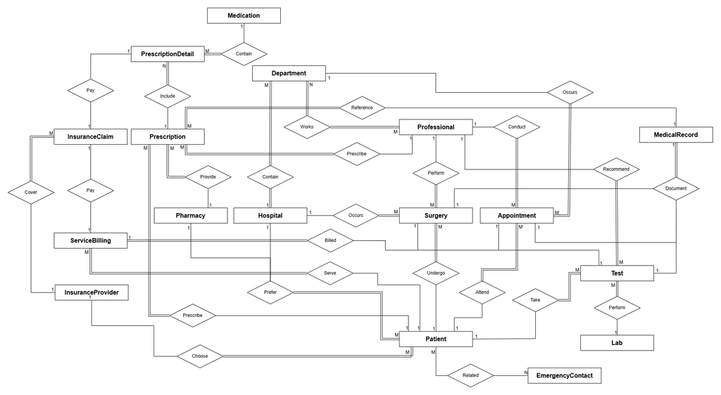

```python
from IPython.display import Image, display

display(Image(filename='ER Diagram.png'))
```

### Diagram Attributes

**Patient**

patient_id, name, date_of_birth, gender, address

**EmergencyContact**

emergency_contact_id, name, phone_number, address

**Hospital**

hospital_id, name, location, contact_number

**Department**

department_id, name, head_of_department

**Professional**

professional_id, name, role

**Pharmacy**

pharmacy_id, name, location, contact_number, operating_hours, manager_name, website, services_offered

**Lab**

lab_id, name, location, contact_number, test_type

**Appointment**

appointment_id, date, time

**Surgery**

surgery_id, date, notes, post-operative_care, outcome

**Test**

test_id, name, results, date, billing_type

**MedicalRecord**

diagnosis, notes

**Medication**

medication_id, name, manufacturer, dosage_form, strength, price

**Prescription**

prescription_id

**PrescriptionDetail**

recommended_dosage, quantity, total_billing_amount, start_date, end_date

**ServiceBilling**

billing_id, amount, payment_status, amount_paid, payment_date

**InsuranceProvider**

insurance_provider_id, name, contact_number, coverage_type

**InsuranceClaim**

claim_id, claim_status, claim_status_reason, amount_claimed, approved_amount, date, approval_date

### Appointments_Data:

**Appointments_Data**

*Appointment_ID (PK), Patient_ID, Appointment_Date, Appointment_Time, Appointment_Status, Patient_Name, Patient_Date_Of_Birth, Patient_Gender, Patient_Address, Patient_Preferred_Hospital_ID, Patient_Preferred_Pharmacy_ID, Patient_Preferred_Insurance_Provider, Emergency_Contact_Relationship, Emergency_Contact_ID (PK), Emergency_Contact_Name, Emergency_Contact_Phone, Emergency_Contact_Address, Professional_ID, Professional_Name, Professional_Role, Department_ID (PK), Department_Name, Head_Of_Department, Hospital_ID, Hospital_Name, Hospital_Location, Hospital_Contact*

**Composite Key** - *Appointment_ID, Emergency_Contact_ID, Department_ID*

**First Normal Form (1NF)** - This table is in 1NF as there are no multi-values attributes or repeating groups.

**Second Normal Form (2NF)** - In order to be in 2NF we need to remove any partial dependencies.

**Partial Dependencies:**

1. *{Appointment_ID} → {Patient_ID, Appointment_Date, Appointment_Time, Appointment_Status, Patient_Name, Patient_Date_Of_Birth, Patient_Gender, Patient_Address, Patient_Preferred_Hospital_ID, Patient_Preferred_Pharmacy_ID, Patient_Preferred_Insurance_Provider, Professional_ID, Professional_Name, Professional_Role}.*
   - Create **Appointment**.
2. *{Emergency_Contact_ID} → {Emergency_Contact_ID, Emergency_Contact_Phone, Emergency_Contact_Address}.*
   - Create **Emergency_Contact**.
3. *{Appointment_ID, Emergency_Contact_ID} → {Emergency_Contact_Relationship}.*
   - Create **Appointment_Emergency_Contact** to represent the relationship.
4. *{Department_ID} → {Department_Name, Head_Of_Department, Hospital_ID, Hospital_Name, Hospital_Location, Hospital_Contact}.*
   - Create **Department**.
5. *{Appointment_ID, Department_ID} → {Professional_Role}*
   - Create **Appointment_Department**.

**Resulting 2NF Tables:**

| **Appointments_Data** |
| --- |
| *Appointment_ID, Emergency_Contact_ID, Department_ID* |

| **Appointment** |
| --- |
| *Appointment_ID (PK), Patient_ID, Appointment_Date, Appointment_Time, Appointment_Status, Patient_Name, Patient_Date_Of_Birth, Patient_Gender, Patient_Address, Patient_Preferred_Hospital_ID, Patient_P… |

| **Emergency_Contact** |
| --- |
| *Emergency_Contact_ID (PK), Emergency_Contact_Name, Emergency_Contact_Phone, Emergency_Contact_Address* |

| **Appointment_Emergency_Contact (For the M-M relationship)** |
| --- |
| *Emergency_Contact_ID (PK, FK to Emergency_Contact), Appointment_ID (PK), Emergency_Contact_Relationship* |

| **Department** |
| --- |
| *Department_ID (PK), Department_Name, Head_Of_Department, Hospital_ID, Hospital_Name, Hospital_Location, Hospital_Contact* |

| **Appointment_Department** |
| --- |
| *Department_ID (PK, FK to Department), Appointment_ID (PK, FK to Appointment), Professional_Role* |

**Third Normal Form (3NF)** - Remove any transitive dependencies, leaving behind only the attributes that are fully dependent on the key.

**Full Functional Dependencies:**

1. *{Appointment_ID} → {Appointment_Date, Appointment_Time, Appointment_Status, Patient_ID, Professional_ID}.*
   - Update **Appointment**.
2. *{Department_ID} → {Department_Name, Head_Of_Department}*
   - Update **Department**.

**Transitive Dependencies:**

1. *{Appointment_ID} → {Patient_ID} → {Patient_Name, Patient_Date_Of_Birth, Patient_Gender, Patient_Address, Patient_Preferred_Hospital_ID, Patient_Preferred_Pharmacy_ID, Patient_Preferred_Insurance_Provider}.*
   - Create **Patient**.
2. *{Appointment_ID, Emergency_Contact_ID} → {Patient_ID, Emergency_Contact_ID} → {Emergency_Contact_Relationship}*

   Create **Patient_Emergency_Contact**.
3. *{Appointment_ID} → {Professional_ID} → {Professional_Name}.*
   - Create **Professional**, update *Professional_ID* in **Appointment** foreign key
4. *{Appointment_ID, Department_ID} → {Professional_ID, Department_ID} → {Professional_Role}*
   - Create **Department_Professional**.
5. *{Department_ID} → {Hospital_ID} → {Hospital_Name, Hospital_Location, Hospital_Contact}.*
   - Create **Hospital**, update *Hospital_ID* in **Department** to foreign key.

**Resulting 3NF Tables:**

| **Patient** |
| --- |
| *Patient_ID (PK), Patient_Name, Patient_Date_Of_Birth, Patient_Gender, Patient_Address, Patient_Preferred_Hospital_ID (FK to Hospital), Patient_Preferred_Pharmacy_ID, Patient_Preferred_Insurance_Provi… |

| **Hospital** |
| --- |
| *Hospital_ID (PK), Hospital_Name, Hospital_Location, Hospital_Contact* |

| **Updated Appointment (Patient_ID and Professional_ID become foreign keys)** |
| --- |
| *Appointment_ID (PK), Patient_ID (FK to Patient), Professional_ID (FK to Professional), Appointment_Date, Appointment_Time, Appointment_Status* |

| **Emergency_Contact** |
| --- |
| *Emergency_Contact_ID (PK), Emergency_Contact_Name, Emergency_Contact_Phone, Emergency_Contact_Address* |

| **Patient_Emergency_Contact** |
| --- |
| *Emergency_Contact_ID (PK, FK to Emergency_Contact), Patient_ID (PK, FK to Patient), Emergency_Contact_Relationship* |

| **Updated Department (Hospital_ID becomes a foreign key)** |
| --- |
| *Department_ID (PK), Department_Name, Head_Of_Department, Hospital_ID (FK to Hospital)* |

| **Professional** |
| --- |
| *Professional_ID (PK), Professional_Name* |

| **Department_Professional (For the M-M relationship)** |
| --- |
| *Department_ID (PK, FK to Department), Professional_ID (PK, FK to Professional), Professional_Role* |

### Prescription_Billing_Insurance_Data:

**Prescription_Billing_Insurance_Data**

*Prescription_ID, Record_ID, Pharmacy_ID, Prescription_Detail_ID, Medication_ID, Medication_Dosage, Medication_Quantity, Total_Medication_Billing_Amount, Dosage_Start_Date, Dosage_End_Date, Pharmacy_Name, Pharmacy_Location, Pharmacy_Contact, Pharmacy_Email, Pharmacy_Operating_Hours, Pharmacy_Manager_Name, Pharmacy_Website, Pharmacy_Services_Offered, Medication_Name, Manufacturer, Medication_Dosage_Form, Medication_Strength, Medication_Price, Claim_ID (PK), Claim_Status, Claim_Status_Reason, Claim_Amount, Approved_Amount, Claim_Date, Approval_Date, Insurance_Provider_ID, Insurance_Provider_Name, Insurance_Provider_Contact, Insurance_Provider_Coverage_Type.*

**Primary Key** - *Claim_ID*

**1NF** - This table is in 1NF as there are no multi-value attributes or repeating groups.

**2NF** - This table is in 2NF as there is a single attribute key.

**3NF** - Remove any transitive dependencies, leaving behind only the attributes that are fully dependent on the key.

**Full Functional Dependencies:**

1. *{Claim_ID} → {Prescription_Detail_ID, Insurance_Provider_ID, Claim_Status, Claim_Status_Reason, Claim_Amount, Approved_Amount, Claim_Date, Approval_Date}.*
   - Create **Claim**.

**Transitive Dependencies:**

2. *{Claim_ID} → {Pharmacy_ID} → {Pharmacy_Name, Pharmacy_Location, Pharmacy_Contact, Pharmacy_Email, Pharmacy_Operating_Hours, Pharmacy_Manager_Name, Pharmacy_Website, Pharmacy_Services_Offered}.*
   - Create **Pharmacy**, update *Pharmacy_ID* in **Patient** to foreign key.
3. *{Claim_ID} → {Prescription_Detail_ID} → {Prescription_ID, Medication_ID, Medication_Dosage, Medication_Quantity, Total_Medication_Billing_Amount, Dosage_Start_Date, Dosage_End_Date}.*
   - Create **Prescription_Detail**.
4. *{Claim_ID} → {Prescription_ID} → {Pharmacy_ID, Record_ID}.*
   - Create **Prescription**.
5. *{Claim_ID} → {Medication_ID} → {Medication_Name, Manufacturer, Medication_Dosage_Form, Medication_Strength, Medication_Price}.*
   - Create **Medication**.
6. *{Claim_ID} → {Insurance_Provider_ID} → {Insurance_Provider_Name, Insurance_Provider_Contact, Insurance_Provider_Coverage_Type}.*
   - Create **Insurance_Provider**, update *Insurance_Provider_ID* in **Patient** to foreign key.

**Resulting 3NF Tables:**

| **Claim** |
| --- |
| *Claim_ID (PK), Prescription_Detail_ID (FK to Prescription_Detail), Insurance_Provider_ID (FK to Insurance_Provider), Claim_Status, Claim_Status_Reason, Claim_Amount, Approved_Amount, Claim_Date, Appr… |

| **Pharmacy** |
| --- |
| *Pharmacy_ID (PK), Pharmacy_Name, Pharmacy_Location, Pharmacy_Contact, Pharmacy_Email, Pharmacy_Operating_Hours, Pharmacy_Manager_Name, Pharmacy_Website, Pharmacy_Services_Offered* |

| **Prescription** |
| --- |
| *Prescription_ID (PK), Record_ID, Pharmacy_ID (FK to Pharmacy)* |

| **Medication** |
| --- |
| *Medication_ID (PK), Medication_Name, Medication_Manufacuturer, Medication_Dosage_Form, Medication_Strength, Medication_Price* |

| **Prescription_Detail** |
| --- |
| *Prescription_Detail_ID (PK), Prescription_ID (FK to Prescription), Medication_ID (FK to Medication), Medication_Dosage, Medication_Quantity, Total_Medication_Billing_Amount, Dosage_Start_Date, Dosage… |

| **Insurance_Provider** |
| --- |
| *Insurance_Provider_ID (PK), Insurance_Provider_Name, Insurance_Provider_Contact, Insurance_Provider_Coverage_Type* |

| **Updated Patient (Pharmacy_ID and Insurance_Provider_ID become foreign keys)** |
| --- |
| *Patient_ID (PK), Patient_Name, Patient_Date_Of_Birth, Patient_Gender, Patient_Address, Patient_Preferred_Hospital_ID (FK to Hospital), Patient_Preferred_Pharmacy_ID (FK to Pharmacy), Patient_Preferre… |

### Service_Billing_Data

**Service_Billing_Insurance_Data**

*Claim_ID (PK), Claim_Status, Claim_Status_Reason, Claim_Amount, Approved_Amount, Claim_Date, Approval_Date, Insurance_Provider_ID, Insurance_Provider_Name, Insurance_Provider_Contact, Insurance_Provider_Coverage_Type, Service_Billing_ID, Appointment_ID, Surgery_ID, Test_ID, Service_Billing_Amount, Service_Billing_Payment_Status, Service_Billing_Amount_Payed, Service_Billing_Payment_Date.*

**Primary Key** - *Claim_ID*

**1NF** - This table is in 1NF as there are no multi-value attributes or repeating groups.

**2NF** - This table is in 2NF as there is a single attribute key.  
**3NF** - Remove any transitive dependencies, leaving behind only the attributes that are fully dependent on the key.

**Full Functional Dependencies:**

1. *{Claim_ID} → {Service_Billing_ID, Insurance_Provider_ID, Claim_Status, Claim_Status_Reason, Claim_Amount, Approved_Amount, Claim_Date, Approval_Date}*
   - Move data into **Claim**, adding *Service_Billing_ID* foreign key.

**Transitive Dependencies:**

1. *{Claim_ID} → {Insurance_Provider_ID} → {Insurance_Provider_Name, Insurance_Provider_Contact, Insurance_Provider_Coverage_Type}*
   - Move data into **Insurance_Provider table**.
2. *{Claim_ID} → {Service_Billing_ID} → {Appointment_ID, Surgery_ID, Test_ID, Service_Billing_Amount, Service_Billing_Payment_Status, Service_Billing_Amount_Payed, Service_Billing_Payment_Date}.*
   - Create **Service_Billing**.

**Resulting 3NF Tables:**

| **Service_Billing** |
| --- |
| *Service_Billing_ID (PK), Appointment_ID (FK to Appointment), Surgery_ID, Test_ID, Service_Billing_Amount, Service_Billing_Payment_Status, Service_Billing_Amount_Payed, Service_Billing_Payment_Date* |

| **Updated Claim (Add new data, adding Service_Billing_ID foreign key)** |
| --- |
| *Claim_ID (PK), Service_Billing_ID (FK to Service_Billing), Prescription_Detail_ID (FK to Prescription_Detail), Insurance_Provider_ID (FK to Insurance_Provider), Claim_Status, Claim_Status_Reason, Cla… |

| **Updated Insurance_Provider (With new data)** |
| --- |
| *Insurance_Provider_ID (PK), Insurance_Provider_Name, Insurance_Provider_Contact, Insurance_Provider_Coverage_Type* |

### Medical_Appointments_Data:

| **Medical_Appointments_Data** |
| --- |
| *Record_ID (PK), Diagnosis, Notes, Appointment_ID, Surgery_ID, Test_ID, Patient_ID, Appointment_Date, Appointment_Time, Appointment_Status* |

**Primary Key** - *Record_ID*

**1NF** - This table is in 1NF as there are no multi-value attributes or repeating groups.

**2NF** - This table is in 2NF as there is a single attribute key.

**3NF** - Remove any transitive dependencies, leaving behind only the attributes that are fully dependent on the key.

**Full Functional Dependencies:**

1. *{Record_ID} → {Diagnosis, Notes, Appointment_ID, Surgery_ID, Test_ID}.*
   - Create **Medical_Record**, update *Record_ID* in **Prescription** to foreign key.

**Transitive Dependencies:**

1. *{Record_ID} → {Appointment_ID} → {Patient_ID, Appointment_Date, Appointment_Time, Appointment_Status}.*
   - Move data into **Appointment**.

**Resulting 3NF Tables:**

| **Medical_Record** |
| --- |
| *Record_ID (PK), Diagnosis, Notes, Appointment_ID (FK to Appointment), Surgery_ID, Test_ID* |

| **Updated Appointment (Add new data)** |
| --- |
| *Appointment_ID (PK), Patient_ID (FK to Patient), Professional_Name, Appointment_Date, Appointment_Time, Appointment_Status* |

| **Updated Prescription (Record_ID becomes a foreign key)** |
| --- |
| *Prescription_ID (PK), Record_ID (FK to Medical_Record), Pharmacy_ID (FK to Pharmacy)* |

### Medical_Surgeries_Data:

| **Medical_Surgeries_Data** |
| --- |
| *Record_ID (PK), Diagnosis, Notes, Appointment_ID, Surgery_ID, Test_ID, Patient_ID, Surgery_Professional_ID, Surgery_Hospital_ID, Surgery_Date, Surgery_Type, Surgery_Notes, Surgery_Post_Operative_Care… |

**Primary Key** - *Record_ID*

**1NF** - This table is in 1NF as there are no multi-value attributes or repeating groups.

**2NF** - This table is in 2NF as there is a single attribute key.

**3NF** Remove any transitive dependencies, leaving behind only the attributes that are fully dependent on the key.

**Full Functional Dependencies:**

1. *{Record_ID} → {Diagnosis, Notes, Appointment_ID, Surgery_ID, Test_ID}.*
   - Move data into **Medcial_Record**.

**Transitive Dependencies:**

1. *{Record_ID} → {Surgery_ID} → {Patient_ID, Surgery_Professional_ID, Surgery_Hospital_ID, Surgery_Date, Surgery_Type, Surgery_Notes, Surgery_Post_Operative_Care, Surgery_Outcome}.*
   - Create **Surgery**, update *Surgery_ID* in **Medical_Record** and **Service_Billing** to foreign key.

**Resulting Tables:**

| **Create Surgery** |
| --- |
| *Surgery_ID (PK), Patient_ID (FK to Patient), Surgery_Professional_ID (FK to Professional), Surgery_Hospital_ID (FK to Hospital), Surgery_Date, Surgery_Type, Surgery_Notes, Surgery_Post_Operative_Care… |

| **Updated Medical_Record (Add new data, Surgery_ID becomes a foreign key)** |
| --- |
| *Record_ID (PK), Diagnosis, Notes, Appointment_ID (FK to Appointment), Surgery_ID (FK to Surgery), Test_ID* |

| **Updated Service_Billing (Surgery_ID becomes a foreign key)** |
| --- |
| *Service_Billing_ID (PK), Appointment_ID (FK to Appointment), Surgery_ID (FK to Surgery), Test_ID, Service_Billing_Amount, Service_Billing_Payment_Status, Service_Billing_Amount_Payed, Service_Billing… |

### Medical_Tests_Data:

| **Medical_Tests_Data:** |
| --- |
| *Record_ID (PK), Diagnosis, Notes, Appointment_ID, Surgery_ID, Test_ID, Lab_ID, Lab_Name, Lab_Location, Lab_Contact, Lab_Type, {Patient_ID, Test_Recommended_By_Professional_ID, Test_Name, Test_Results… |

**Primary Key** - *Record_ID*

**1NF** - This table is in 1NF as there are no multi-value attributes or repeating groups.

**2NF** - This table is in 2NF as there is a single attribute key.

**3NF** - Remove any transitive dependencies, leaving behind only the attributes that are fully dependent on the key.

**Full Functional Dependencies:**

1. *{Record_ID} → {Diagnosis, Notes, Appointment_ID, Surgery_ID, Test_ID}.*
   - Move data into **Medical_Record**.

**Transitive Dependencies:**

1. *{Record_ID} → {Lab_ID} → {Lab_Name, Lab_Location, Lab_Contact, Lab_Type}.*
   - Create **Lab**.
2. *{Record_ID} → {Test_ID} → {Patient_ID, Test_Recommended_By_Professional_ID, Test_Name, Test_Results, Test_Date, Test_Billing_Type}.*
   - Create **Test**, update *Test_ID* in **Medical_Record** and **Service_Billing** to foreign key.

**Resulting 3NF tables:**

| **Create Lab** |
| --- |
| *Lab_ID (PK), Lab_Name, Lab_Location, Lab_Contact, Lab_Type* |

| **Create Test** |
| --- |
| *Test_ID (PK), Patient_ID (FK to Patient), Test_Recommended_By_Professional_ID (FK to Professional), Test_Name, Test_Results, Test_Date, Test_Billing_Type* |

| **Update Medical_Record (Add data, Test_ID becomes a foreign key)** |
| --- |
| *Record_ID (PK), Diagnosis, Notes, Appointment_ID (FK to Appointment), Surgery_ID (FK to Surgery), Test_ID (FK to Test)* |

| **Update Service_Billing (Test_ID becomes a foreign key)** |
| --- |
| *Service_Billing_ID (PK), Appointment_ID (FK to Appointment), Surgery_ID (FK to Surgery), Test_ID (FK to Test), Service_Billing_Amount, Service_Billing_Payment_Status, Service_Billing_Amount_Payed, Se… |

### Fully Normalised Tables:

| **Patient** |
| --- |
| *Patient_ID (PK), Patient_Name, Patient_Date_Of_Birth, Patient_Gender, Patient_Address, Patient_Preferred_Hospital_ID (FK to Hospital), Patient_Preferred_Pharmacy_ID (FK to Pharmacy), Patient_Preferre… |

| **Emergency_Contact** |
| --- |
| *Emergency_Contact_ID (PK), Emergency_Contact_Name, Emergency_Contact_Phone, Emergency_Contact_Address* |

| **Patient_Emergency_Contact** |
| --- |
| *Patient_ID (PK, FK to Patient), Emergency_Contact_ID (PK, FK to Emergency_Contact), Emergency_Contact_Relationship* |

| **Professional** |
| --- |
| *Professional_ID (PK), Professional_Name* |

| **Hospital** |
| --- |
| *Hospital_ID (PK), Hospital_Name, Hospital_Location, Hospital_Contact* |

| **Department** |
| --- |
| *Department_ID (PK), Department_Name, Head_Of_Department, Hospital_ID (FK to Hospital)* |

| **Department_Professional** |
| --- |
| *Department_ID (FK to Department), Professional_ID (FK to Professional), Professional_Role* |

| **Pharmacy** |
| --- |
| *Pharmacy_ID (PK), Pharmacy_Name, Pharmacy_Location, Pharmacy_Contact, Pharmacy_Email, Pharmacy_Operating_Hours, Pharmacy_Manager_Name, Pharmacy_Website, Pharmacy_Services_Offered* |

| **Appointment** |
| --- |
| *Appointment_ID (PK), Appointment_Date, Appointment_Time, Appointment_Status, Patient_ID (FK to Patient), Professional_ID (FK to Professional)* |

| **Surgery** |
| --- |
| *Surgery_ID (PK), Surgery_Date, Surgery_Type, Surgery_Notes, Surgery_Post_Operative_Care, Surgery_Outcome, Patient_ID (FK to Patient) , Surgery_Professional_ID (FK to Professional), Hopsital_ID (FK to… |

| **Lab** |
| --- |
| *Lab_ID (PK), Lab_Name, Lab_Location, Lab_Contact, Test_Type* |

| **Test** |
| --- |
| *Test_ID (PK), Test_Name, Test_Results, Test_Date, Test_Billing_Type, Patient_ID (FK to Patient), Test_Recommended_By_Professional_ID (FK to Professional), Lab_ID (FK to Lab)* |

| **Medical_Record** |
| --- |
| *Record_ID (PK), Diagnosis, Notes* |

| **Appointment_Medical_Record** |
| --- |
| *Record_ID (FK to Medical_Record), Appointment_ID (FK to Appointment).* |

| **Surgery_Medical_Record** |
| --- |
| *Record_ID (FK to Medical_Record), Surgery_ID (FK to Surgery).* |

| **Test_Medical_Record** |
| --- |
| *Record_ID (FK to Medical_Record), Test_ID (FK to Test).* |

| **Medication** |
| --- |
| *Medication_ID (PK), Medication_Name, Manufacturer, Medicine_Dosage_Form, Medication_Strength, Medication_Price.* |

| **Prescription** |
| --- |
| *Prescription_ID (PK), Pharmacy_ID (FK to Pharmacy), Record_ID (FK to Medical_Record).* |

| **Prescription_Detail** |
| --- |
| *Prescription_Details_ID (PK), Medication_Dosage, Medication_Quantity, Total_Medication_Billing_Amount, Dosage_Start_Date, Dosage_End_Date, Prescription_ID (FK to Prescription), Medication_ID (FK to M… |

| **Service_Billing** |
| --- |
| *Service_Billing_ID (PK), Service_Billing_Amount, Service_Billing_Payment_Status, Service_Billing_Amount_Paid, Service_Billing_Payment_Date, Patient_ID (FK).* |

| **Appointment_Service_Billing** |
| --- |
| *Service_Billing_ID (FK to Service_Billing), Appointment_ID (FK to Appointment).* |

| **Surgery_Service_Billing** |
| --- |
| *Service_Billing_ID (FK to Service_Billing), Surgery_ID (FK to Surgery).* |

| **Test_Service_Billing** |
| --- |
| *Service_Billing_ID (FK to Service_Billing), Test_ID (FK to Test).* |

| **Claim** |
| --- |
| *Claim_ID (PK), Claim_Status, Claim_Reason, Claim_Amount, Approved_Amount, Claim_Date, Approval_Date, Insurance_Provider_ID (FK).* |

| **Prescription_Claim** |
| --- |
| *Claim_ID (FK to Claim), Prescription_Detail_ID (FK to Prescription_Medication).* |

| **Service_Claim** |
| --- |
| *Claim_ID (FK to Claim), Service_Billing_ID (FK to Service_Billing).* |

| **Insurance_Provider** |
| --- |
| *Insurance_Provider_ID (PK), Insurance_Provider_Name, Insurance_Provider_Contact, Insurance_Provider_Coverage_Type.* |

### Checks And Changes Made Before Implementing In SQL

**Professional_ID missing from Appointments_Data, Professional_Name and Professional_Role missing from Medical_Surgeries_Data and Medical_Tests_Data, so created a new Professional_ID and a mapping table**

```
CREATE TABLE Professional_Mapping AS

WITH Combined_Professionals AS (

SELECT DISTINCT Professional_Name, Professional_Role, NULL AS Old_Professional_ID
FROM Appointments_Data
WHERE Professional_Name IS NOT NULL AND Professional_Role IS NOT NULL

UNION

SELECT DISTINCT NULL AS Professional_Name, NULL AS Professional_Role, Surgery_Professional_ID AS Old_Professional_ID
FROM Medical_Surgeries_Data
WHERE Surgery_Professional_ID IS NOT NULL

UNION

SELECT DISTINCT NULL AS Professional_Name, NULL AS Professional_Role, Test_Recommended_By_Professional_ID AS Old_Professional_ID
FROM Medical_Tests_Data
WHERE Test_Recommended_By_Professional_ID IS NOT NULL
),

Generated_Professionals AS (
SELECT 'PR' || ROW_NUMBER() OVER () AS New_Professional_ID, Old_Professional_ID, Professional_Name, Professional_Role
FROM Combined_Professionals
)

SELECT *
FROM Generated_Professionals
ORDER BY CAST(SUBSTR(New_Professional_ID, 3) AS INTEGER)
```

**All Patient data is in Appointments_Data as these return nothing**

```
SELECT DISTINCT Patient_ID
FROM Medical_Appointments_Data
WHERE Patient_ID NOT IN (SELECT Patient_ID FROM Appointments_Data)

SELECT DISTINCT Patient_ID
FROM Medical_Surgeries_Data
WHERE Patient_ID NOT IN (SELECT Patient_ID FROM Appointments_Data)

SELECT DISTINCT Patient_ID
FROM Medical_Tests_Data
WHERE Patient_ID NOT IN (SELECT Patient_ID FROM Appointments_Data)
```

### Creating The Tables

**Professional**

```
CREATE TABLE Professional AS

SELECT New_Professional_ID AS Professional_ID, Professional_Name, Professional_Role

FROM Professional_Mapping
```

**Surgery**

```
CREATE TABLE Surgery AS

SELECT s.Surgery_ID, s.Patient_ID, m.New_Professional_ID, s.Surgery_Hospital_ID, s.Surgery_Date, s.Surgery_Type, s.Surgery_Notes, s.Surgery_Outcome, s.Surgery_Post_Operative_Care

FROM Medical_Surgeries_Data s
JOIN Professional_Mapping m ON m.Old_Professional_ID = s.Surgery_Professional_ID

ORDER BY CAST(SUBSTR(Surgery_ID, 3) AS INTEGER)
```

**Test**

```
CREATE TABLE Test AS

SELECT t.Test_ID,t. Patient_ID, m.New_Professional_ID AS Test_Recommended_By_Professional_ID, t.Test_Name, t.Test_Results, t.Test_Date, Test_Billing_Type, Lab_ID

FROM Medical_Tests_Data t
JOIN Professional_Mapping m ON m.Old_Professional_ID = t.Test_Recommended_By_Professional_ID

ORDER BY CAST(SUBSTR(Test_ID, 2) AS INTEGER)
```

**Patient**

```
CREATE TABLE Patient AS

SELECT DISTINCT Patient_ID, Patient_Name, Patient_Date_Of_Birth, Patient_Gender, Patient_Address, Patient_Preferred_Hospital_ID, Patient_Preferred_Pharmacy_ID, Patient_Preferred_Insurance_Provider_ID

FROM Appointments_Data

ORDER BY CAST(substr(Patient_ID, 2) AS INTEGER)
```

**Emergency_Contact**

```
CREATE TABLE Emergency_Contact AS

SELECT 'EC' || ROW_NUMBER() OVER () AS Emergency_Contact_ID, Emergency_Contact_Name, Emergency_Contact_Phone, Emergency_Contact_Address

FROM(
SELECT DISTINCT Emergency_Contact_Name, Emergency_Contact_Phone, Emergency_Contact_Address

FROM Appointments_Data
)

ORDER BY CAST(substr(Emergency_Contact_ID, 3) AS INTEGER)
```

**Patient_Emergency_Contact**

```
CREATE TABLE Patient_Emergency_Contact AS

SELECT DISTINCT a.Patient_ID, e.Emergency_Contact_ID

FROM Appointments_Data a

JOIN Emergency_Contact e ON a.Emergency_Contact_Address = e.Emergency_Contact_Address

ORDER BY CAST(substr(Patient_ID, 2) AS INTEGER)
```

**Department**

```
CREATE TABLE Department AS

SELECT DISTINCT Department_ID, Department_Name, Head_Of_Department, Hospital_ID

FROM Appointments_Data

ORDER BY CAST(substr(Department_ID, 2) AS INTEGER)
```

**Department_Professional**

```
CREATE TABLE Department_Professional AS

SELECT DISTINCT d.Department_ID, p.Professional_ID

FROM Appointments_Data d

JOIN Professional p ON
d.Professional_Name = p.Professional_Name
AND
d.Professional_Role = p.Professional_Role
```

**Appointment**

```
CREATE TABLE Appointment AS

SELECT DISTINCT a.Appointment_ID, a.Patient_ID, p.Professional_ID, a.Appointment_Date, a.Appointment_Time, a.Appointment_Status

FROM Appointments_Data a
JOIN Professional p ON
a.Professional_Name = p.Professional_Name
AND
a.Professional_Role = p.Professional_Role

ORDER BY CAST(substr(Appointment_ID, 2) AS INTEGER)
```

**Hospital**

```
CREATE TABLE Hospital AS

SELECT DISTINCT Hospital_ID, Hospital_Name, Hospital_Location

FROM Appointments_Data

ORDER BY CAST(substr(Hospital_ID, 2) AS INTEGER)
```

**Pharmacy**

```
CREATE TABLE Pharmacy AS

SELECT DISTINCT Pharmacy_ID, Pharmacy_Name, Pharmacy_Location, Pharmacy_Contact, Pharmacy_Email, Pharmacy_Operating_Hours, Pharmacy_Manager_Name, Pharmacy_Website, Pharmacy_Services_Offered

FROM Prescription_Billing_Insurance_Data

ORDER BY CAST(SUBSTR(Pharmacy_ID, 3) AS INTEGER);
```

**Lab**

```
CREATE TABLE Lab as

SELECT DISTINCT Lab_ID, Lab_Name, Lab_Location, Lab_Contact, Lab_Type

FROM Medical_Tests_Data

ORDER BY CAST(SUBSTR(Lab_ID, 2) AS INTEGER);
```

**Medical_Record**

```
CREATE TABLE Medical_Record AS

SELECT * FROM
(
SELECT Record_ID, Diagnosis, Notes

FROM Medical_Appointments_Data

UNION

SELECT Record_ID, Diagnosis, Notes

FROM Medical_Surgeries_Data

UNION

SELECT Record_ID, Diagnosis, Notes FROM Medical_Tests_Data
)

ORDER BY CAST(SUBSTR(Record_ID, 3) AS INTEGER);
```

**Appointment_Medical_Record**

```
CREATE TABLE Appointment_Medical_Record AS

SELECT Record_ID, Appointment_ID

FROM Medical_Appointments_Data

ORDER BY CAST(substr(Record_ID, 3) AS INTEGER)
```

**Surgery_Medical_Record**

```
CREATE TABLE Surgery_Medical_Record AS

SELECT Record_ID, Surgery_ID

FROM Medical_Surgeries_Data

ORDER BY CAST(substr(Record_ID, 3) AS INTEGER)
```

**Test_Medical_Record**

```
CREATE TABLE Test_Medical_Record AS

SELECT Record_ID, Test_ID

FROM Medical_Tests_Data

ORDER BY CAST(substr(Record_ID, 3) AS INTEGER)
```

**Medication**

```
CREATE TABLE Medication AS

SELECT DISTINCT Medication_ID, Medication_Name, Manufacturer, Medication_Dosage_Form, Medication_Strength, Medication_Price

FROM Prescription_Billing_Insurance_Data

ORDER BY CAST(SUBSTR(Medication_ID, 2) AS INTEGER);
```

**Prescription Detail**

```
CREATE TABLE Prescription_Detail AS

SELECT Prescription_Detail_ID, Prescription_ID, Medication_ID, Medication_Dosage, Medication_Quantity, Total_Medication_Billing_Amount, Dosage_Start_Date, Dosage_End_Date

FROM Prescription_Billing_Insurance_Data

ORDER BY CAST(SUBSTR(Prescription_Detail_ID, 4) AS INTEGER);
```

**Prescription**

```
CREATE TABLE Prescription AS

SELECT DISTINCT Prescription_ID, Pharmacy_ID, Record_ID

FROM Prescription_Billing_Insurance_Data

ORDER BY CAST(SUBSTR(Prescription_ID, 3) AS INTEGER);
```

**Insurance_Provider**

```
CREATE TABLE Insurance_Provider AS

SELECT * FROM
(
SELECT Insurance_Provider_ID, Insurance_Provider_Name, Insurance_Provider_Contact, Insurance_Provider_Coverage_Type

FROM Prescription_Billing_Insurance_Data

UNION

SELECT Insurance_Provider_ID, Insurance_Provider_Name, Insurance_Provider_Contact, Insurance_Provider_Coverage_Type

FROM Service_Billing_Insurance_Data
)

ORDER BY CAST(SUBSTR(Insurance_Provider_ID, 3) AS INTEGER);
```

**Service_Billing**

```
CREATE TABLE Service_Billing AS

SELECT Service_Billing_ID, Service_Billing_Amount, Service_Billing_Payment_Status, Service_Billing_Amount_Paid, Service_Billing_Payment_Date

FROM Service_Billing_Insurance_Data

ORDER BY CAST(substr(Service_Billing_ID, 3) AS INTEGER)
```

**Appointment_Service_Billing**

```
CREATE TABLE Appointment_Service_Billing AS

SELECT Service_Billing_ID, Appointment_ID

FROM Service_Billing_Insurance_Data

WHERE Appointment_ID IS NOT NULL

ORDER BY CAST(substr(Service_Billing_ID, 3) AS INTEGER)
```

**Surgery_Service_Billing**

```
CREATE TABLE Surgery_Service_Billing AS

SELECT Service_Billing_ID, Surgery_ID

FROM Service_Billing_Insurance_Data

WHERE Surgery_ID IS NOT NULL

ORDER BY CAST(substr(Service_Billing_ID, 3) AS INTEGER)
```

**Test_Service_Billing**

```
CREATE TABLE Test_Service_Billing AS

SELECT Service_Billing_ID, Test_ID

FROM Service_Billing_Insurance_Data

WHERE Test_ID IS NOT NULL

ORDER BY CAST(substr(Service_Billing_ID, 3) AS INTEGER)
```

**Claim**

```
CREATE TABLE Claim AS

SELECT * FROM
(
SELECT Claim_ID, Insurance_Provider_ID, Claim_Status, Claim_Status_Reason, Claim_Amount, Approved_Amount, Claim_Date, Approval_Date

FROM Prescription_Billing_Insurance_Data

UNION

SELECT Claim_ID, Insurance_Provider_ID, Claim_Status, Claim_Status_Reason, Claim_Amount, Approved_Amount, Claim_Date, Approval_Date

FROM Service_Billing_Insurance_Data
)

ORDER BY CAST(substr(Claim_ID, 3) AS INTEGER)
```

**Prescription_Claim**

```
CREATE TABLE Prescription_Claim AS

SELECT Claim_ID, Prescription_Detail_ID

FROM Prescription_Billing_Insurance_Data

ORDER BY CAST(substr(Claim_ID, 3) AS INTEGER)
```

**Service_Claim**

```
CREATE TABLE Service_Claim AS

SELECT Claim_ID, Service_Billing_ID

FROM Service_Billing_Insurance_Data

ORDER BY CAST(substr(Claim_ID, 3) AS INTEGER)
```

## Task 3: Research Design, Implementation, and Results (45 Marks)

Using the database schema designed in Task 2, develop, implement, and analyse **three** distinct modelling solutions (**15 marks each**) to address the Data Intelligence team's aim (as described in the scenario). The three solutions must collectively cover all three of the following categories: inferential statistics, supervised learning, and unsupervised learning, with each solution primarily focusing on one or a combination of these categories. The solutions should be of sufficient complexity to demonstrate a comprehensive understanding of the data and the problem. For each solution, include:

- **Problem**: Clearly and concisely state the specific problem within the NHS context that your solution addresses.
- **Solution**: Detail the design of your solution, including the specific techniques used and how they are combined. Ensure that your design incorporates information from multiple tables in the database where relevant.
- **Justification**: Explain why the selected inferential statistics, supervised learning algorithms, and/or unsupervised learning algorithms are appropriate for the specific problem being addressed.
- **Implementation**: Provide well-commented and organised code (including SQL queries) used to implement your solution. Clearly indicate and justify any modifications made to the database schema or data. Ensure that your code is reproducible.
- **Results**: Present your findings in a clear and concise manner, using appropriate visualisations (charts, graphs, tables) as appropriate. Critically analyse your results, discussing how they can help the NHS address the stated problem.
- **Limitations**: Discuss any limitations of your solution, including potential biases in the data, assumptions made, or areas where the solution could be improved.

**World Limit**: 400 words per solution (1200 words in total for the three solutions). This limit applies only to the explanations. There is no limit on any associated code, commentary on the code, results generated as plots and tables, or figures.

# Problem 1

## Problem

To improve patient care and resource efficiency, it’s important to understand which risk group patients fall into. Patients with poor surgery outcomes or frequent abnormal test results are more likely to need closer monitoring or follow-up care. However, identifying these high-risk individuals is difficult due to the size and separation of the available data. Since patients aren’t already grouped by risk level, professionals have no easy way to prioritise who needs more support or intervention.

## Solution

Using k-means clustering I grouped patients based on patterns in their healthcare data. By extracting data from the tables I can engineer features like surgery outcomes, test results, and appointment history, and automatically form clusters of patients with similar characteristics. The NHS can then use this to catagorise patients and provide more personal care.

## Justification

K-means clustering uncovers hidden structures in data when labels aren’t available. It finds natural groupings without needing expert-labelled risk scores. This makes it ideal for the problem and the data provided. By standardising values and using multiple features of a patient, the algorithm forms risk groups that can highlight overlooked patients.These insights give healthcare staff a clearer starting point for proactive care, even when information is limited.

## Implementation

```python
#Importing necessary libraries
import pandas as pd
from pandas.plotting import parallel_coordinates
import numpy as np
from sklearn.cluster import KMeans
from sklearn.preprocessing import StandardScaler
from sklearn.preprocessing import MinMaxScaler
import matplotlib.pyplot as plt
import seaborn as sns
import sqlite3

con = sqlite3.connect('DATA Assessment DB.db')
```

```python
# Selecting all patients from the Appointment table
appointments = pd.read_sql('SELECT Patient_ID FROM Appointment', con)

# Setting up patient_summary
patient_summary = pd.DataFrame(appointments['Patient_ID'].unique(), columns=['Patient_ID'])

# Selecting all patients and their surgery outcome from Surgery
surgeries = pd.read_sql('SELECT Patient_ID, Surgery_Outcome FROM Surgery', con)

# Encoding surgery outcomes (higher number = worse outcome)
surgery_outcome = {
    'Recovered' : 0,
    'Successful': 1,
    'Partial Success': 2,
    'Unsuccessful': 3,
    'Complications': 4,
    'Infection': 5,
}
surgeries['Surgery_Outcome'] = surgeries['Surgery_Outcome'].map(surgery_outcome)

# Selecting patients their test results and date from Test
tests = pd.read_sql('SELECT Patient_ID, Test_Results, Test_Date FROM Test', con)

con.close()

tests['Test_Date'] = pd.to_datetime(tests['Test_Date'])

# Using binary encoding for test results severity (0 = good, 1 = bad)
good_test_results = [
            'Normal',
            'No cancer detected',
            'No viruses detected',
            'No drugs detected',
            'No issues found'
        ]
test_result = lambda x: 0 if x in good_test_results else 1
tests['Test_Severity'] = tests['Test_Results'].apply(test_result)
```

```python
# Creating a feature for number of appointments per patient
num_appointments = appointments.groupby('Patient_ID').size().reset_index(name='Num_Appointments')

# Merging appointment features
patient_summary = patient_summary.merge(num_appointments, on='Patient_ID', how='left')
```

```python
# Merging surgery features
patient_summary = patient_summary.merge(surgeries, on='Patient_ID', how='left')

# Add flag for having surgery data
patient_summary['Has_Surgery_Data'] = patient_summary['Surgery_Outcome'].notna().astype(int)
```

```python
# Creating features based on tests

# Counting the number of good and bad tests per patient
test_counts = tests.groupby(['Patient_ID', 'Test_Severity']).size().unstack(fill_value=0)
test_counts = test_counts.rename(columns={0: 'Num_Good_Tests', 1: 'Num_Bad_Tests'}).reset_index()

# Getting the severity of the most recent test
last_test_severity = (
     tests.loc[tests.groupby('Patient_ID')['Test_Date'].idxmax(), ['Patient_ID', 'Test_Severity']]
    .reset_index(drop=True)
    .rename(columns={'Test_Severity': 'Last_Test_Severity'})
)

# Merging test features
patient_summary = patient_summary.merge(test_counts, on='Patient_ID', how='left')
patient_summary = patient_summary.merge(last_test_severity, on='Patient_ID', how='left')

# Add flag for having test data
patient_summary['Has_Test_Data'] = patient_summary['Last_Test_Severity'].notna().astype(int)
```

```python
# Dealing with any null values
patient_summary['Num_Appointments'] = patient_summary['Num_Appointments'].fillna(0) # Filled with 0 to signify no appointments
patient_summary['Num_Good_Tests'] = patient_summary['Num_Good_Tests'].fillna(0) # Filled with 0 to signify no good tests
patient_summary['Num_Bad_Tests'] = patient_summary['Num_Bad_Tests'].fillna(0) # Filled with 0 to signify no bad tests
patient_summary['Last_Test_Severity'] = patient_summary['Last_Test_Severity'].fillna(0) # Filled with 0 to signify the patient has had no tests
patient_summary['Surgery_Outcome'] = patient_summary['Surgery_Outcome'].fillna(0) # Filled with 0 to signify patient has had no surgery
```

```python
# Creating a generalised risk score to be use comparatively (higher score = higher risk)
patient_summary['Risk_Score'] = (
    patient_summary['Surgery_Outcome'] * 2 +
    patient_summary['Num_Bad_Tests'] * 0.5 +
    patient_summary['Last_Test_Severity'] * 1
)
```

```python
# Setting the features for the cluster input
X = patient_summary[[
    'Num_Appointments',
    'Num_Bad_Tests',
    'Num_Good_Tests',
    'Last_Test_Severity',
    'Surgery_Outcome',
    'Has_Test_Data',
    'Has_Surgery_Data'
]]
```

```python
# Scaling the values
scaler = StandardScaler()
scaled_features = scaler.fit_transform(X)

# Using a kmeans cluster
kmeans = KMeans(n_clusters=4, init='k-means++', n_init=20, random_state=42)

# Setting each patient to a cluster
patient_summary['Cluster'] = kmeans.fit_predict(scaled_features)
```

```python
# Summarising the clusters
cluster_summary = patient_summary.groupby('Cluster').agg(
    Cluster_Size=('Patient_ID', 'count'),
    Avg_Num_Appointments=('Num_Appointments', 'mean'),
    Avg_Num_Bad_Tests=('Num_Bad_Tests', 'mean'),
    Avg_Num_Good_Tests=('Num_Good_Tests', 'mean'),
    Avg_Last_Test_Severity=('Last_Test_Severity', 'mean'),
    Avg_Surgery_Outcome=('Surgery_Outcome', 'mean'),
    Has_Test_Data_Rate=('Has_Test_Data', 'mean'),
    Has_Surgery_Data_Rate=('Has_Surgery_Data', 'mean'),
    Avg_Risk_Score=('Risk_Score', 'mean')
).reset_index()
```

```python
# Naming the clusters based on risk
cluster_name_map = {
    0: 'Postoperative Risk',
    1: 'Low Risk',
    2: 'Future Risk',
    3: 'Ongoing Risk',
}

# Add a new column for cluster names
cluster_summary['Cluster_Name'] = cluster_summary['Cluster'].map(cluster_name_map)
```

```python
# For plotting a pie chart showing the distribution of the cluster sizes
def plot_cluster_pie_chart():
    sizes = cluster_summary['Cluster_Size']
    labels = cluster_summary['Cluster_Name']
    plt.pie(sizes, labels=labels, autopct='%1.1f%%')
    plt.title('Patient Distribution by Cluster')
    plt.axis('equal')
    plt.show()
```

```python
# For plotting a bar chart of a component for each cluster
def plot_component_bar_chart(component):
        data = cluster_summary[['Cluster_Name', component]].copy()

        data.set_index('Cluster_Name', inplace=True)
        data.plot(kind='bar', cmap='Set2')
        plt.title(f'{component} by Cluster')
        plt.xlabel('Cluster')
        plt.ylabel(component)
        plt.grid(axis='y', alpha=0.5)
        plt.grid(axis='x', alpha=0)
        plt.xticks(rotation=0)
        plt.legend(loc='center left', bbox_to_anchor=(1, 0.5))
        plt.show()
```

```python
# For plotting a stacked bar chart of components for each cluster
def plot_stacked_bar_chart(components):
    data = cluster_summary[components].copy()
    data['Cluster_Name'] = cluster_summary['Cluster_Name']
    data.set_index('Cluster_Name', inplace=True)

    # Scaling the data between 0-1 so a component won't overpower the bar
    scaler = MinMaxScaler()
    data[data.columns] = scaler.fit_transform(data[data.columns])

    data.plot(kind='bar', stacked=True, cmap='Set2')
    plt.title('Contributors to Cluster')
    plt.ylabel('Scaled Proportion of Component')
    plt.xlabel('Cluster')
    plt.grid(axis='y', alpha=0.5)
    plt.grid(axis='x', alpha=0)
    plt.xticks(rotation=0)
    plt.legend(loc='center left', bbox_to_anchor=(1, 0.5))
    plt.show()
```

## Results

```python
for column in cluster_summary.columns:
    print(f'{column}:')
    print(cluster_summary[column])
    print('\n')
```

```
Cluster:
0    0
1    1
2    2
3    3
Name: Cluster, dtype: int32


Cluster_Size:
0     46316
1    327956
2     23049
3      2679
Name: Cluster_Size, dtype: int64


Avg_Num_Appointments:
0    1.471133
1    1.374529
2    1.461278
3    1.526316
Name: Avg_Num_Appointments, dtype: float64


Avg_Num_Bad_Tests:
0     0.006110
1     0.000000
2     1.655777
3    10.137738
Name: Avg_Num_Bad_Tests, dtype: float64


Avg_Num_Good_Tests:
0    0.012415
1    0.000000
2    0.612174
3    4.067563
Name: Avg_Num_Good_Tests, dtype: float64


```

[output cut: 31 more lines]

```

Avg_Risk_Score:
0    5.030562
1    0.000000
2    2.147555
3    6.465286
Name: Avg_Risk_Score, dtype: float64


Cluster_Name:
0    Postoperative Risk
1              Low Risk
2           Future Risk
3          Ongoing Risk
Name: Cluster_Name, dtype: object
```

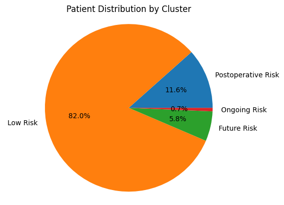

```python
plot_cluster_pie_chart()
```

### Pie chart results

This distribution shows that the majority of patients are low risk, while smaller groups face post-surgery concerns, potential future issues, or ongoing health problems. It highlights where most care is routine and where extra attention may be needed.

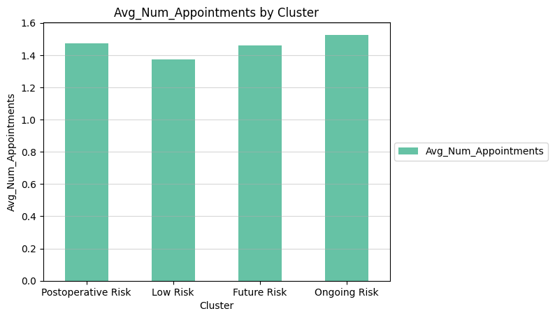

```python
plot_component_bar_chart('Avg_Num_Appointments')
```

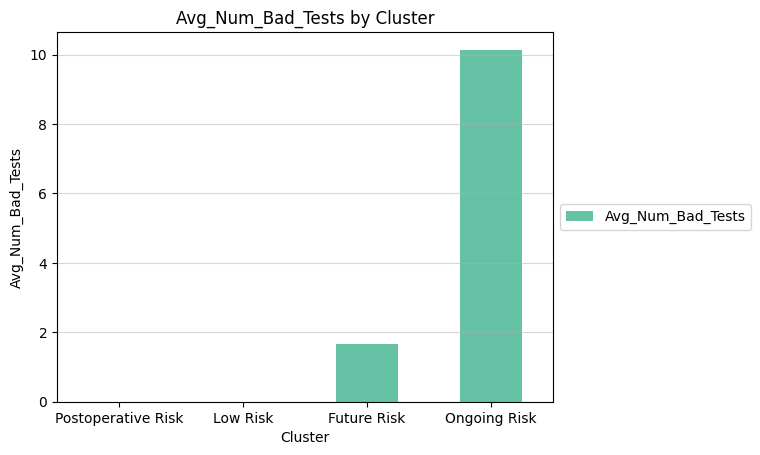

```python
plot_component_bar_chart('Avg_Num_Bad_Tests')
```

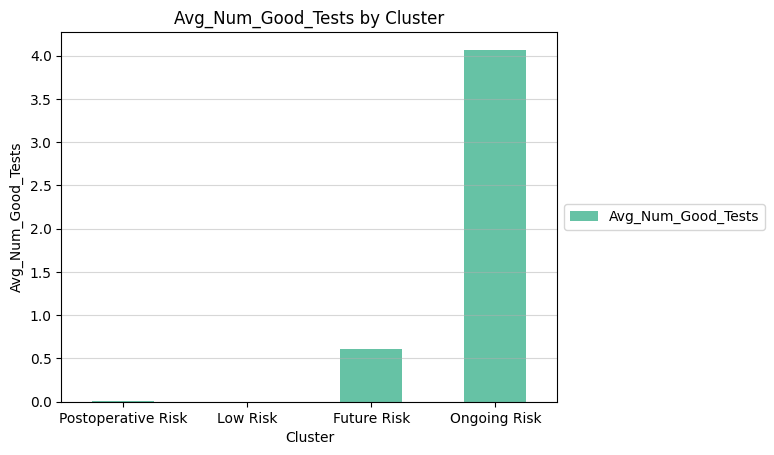

```python
plot_component_bar_chart('Avg_Num_Good_Tests')
```

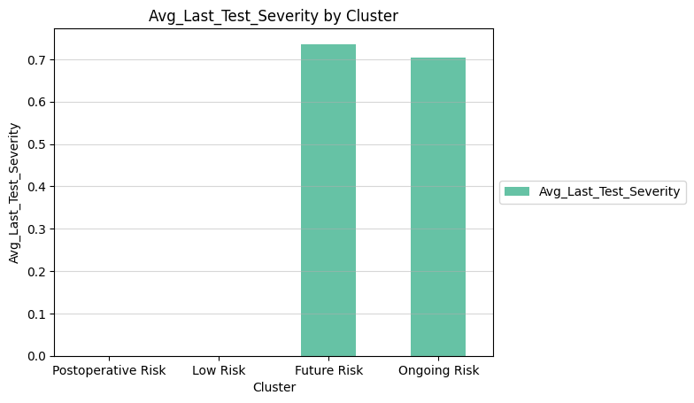

```python
plot_component_bar_chart('Avg_Last_Test_Severity')
```

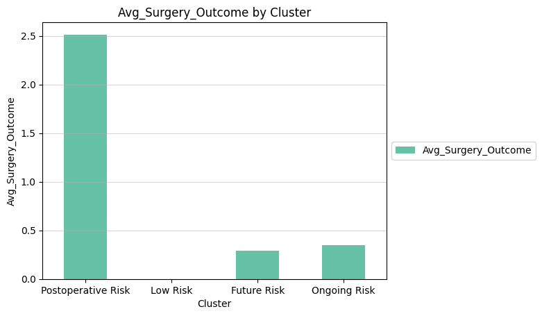

```python
plot_component_bar_chart('Avg_Surgery_Outcome')
```

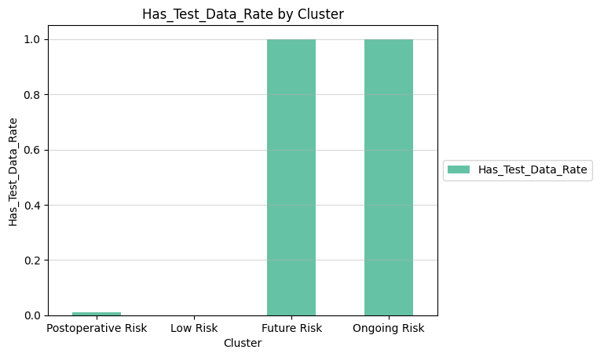

```python
plot_component_bar_chart('Has_Test_Data_Rate')
```

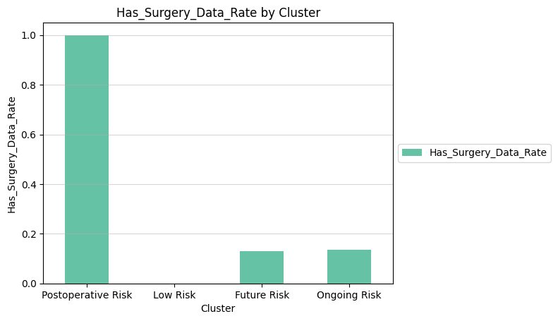

```python
plot_component_bar_chart('Has_Surgery_Data_Rate')
```

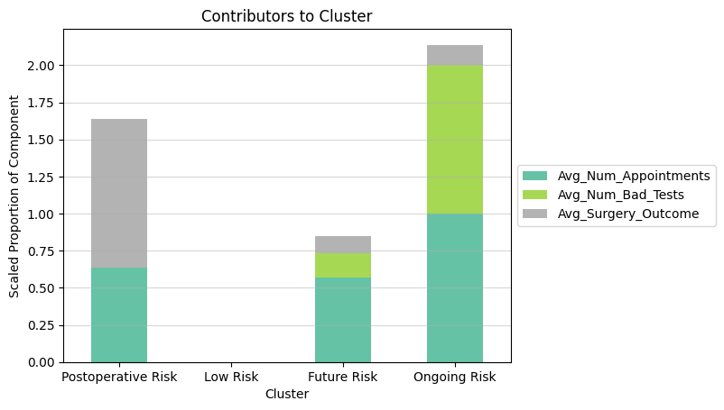

```python
plot_stacked_bar_chart(['Avg_Num_Appointments', 'Avg_Num_Bad_Tests', 'Avg_Surgery_Outcome'])
```

### Bar chart results

From the bar charts, we can see how each feature varies across the different patient groups, the **low risk** group has almost no test or surgery data, and their risk score is zero. The **postoperative risk** group has high surgery outcomes but very few tests, suggesting they are patients with a one time injury or illness requiring postoperative care. The **future risk** cluster shows early signs of concern, with some bad tests and rising severity, but limited surgery data, this represents patients with early signs of illness that may require preventative care. The **ongoing risk** group stands out with high numbers of bad and good tests, high severity, and the highest average risk score, showing they are actively being monitored for chronic issues. This helps explain what characterises each cluster beyond just the risk level. Having seperate groups will allow the NHS to give specialised care and assign the correct resources to patients.

## Limitations

The solution was limited by the quality and size of the data. Many patients had missing or incomplete records, especially for test and surgery outcomes, which reduced the accuracy of the groupings.

# Problem 2

## Problem

Understanding healthcare activity trends across the year is challenging without clear, time-based summaries. Appointments, tests, surgeries, and prescriptions all happen at varying rates throughout the months, but the raw data doesn’t highlight when peaks or dips occur. This makes it harder to plan staffing, anticipate demand for medications, or identify seasonal diagnoses.

## Justification

Monthly visualisation makes it easy to detect trends and compare categories over time, and hypothesis testing allows us to confirm trends between data and find which areas are most impacted, making them best suited to this problem.

## Implementation

```python
# Importing necessary libraries
import pandas as pd
import seaborn as sns
import matplotlib.pyplot as plt
import sqlite3

con = sqlite3.connect('DATA Assessment DB.db')
```

```python
# Initialising the tables we are getting data from
appointments = pd.read_sql('SELECT * FROM Appointment', con)
appointments = appointments[appointments['Appointment_Status'] != 'Scheduled']
tests = pd.read_sql('SELECT * FROM Test', con)
surgeries = pd.read_sql('SELECT * FROM Surgery', con)
```

```python
# A table containing Appointment_Date, Prescription_ID, Pharmacy_ID, Medication_Name, Diagnosis
prescription_information = pd.read_sql('''
SELECT a.Appointment_Date, p.Prescription_ID, p.Pharmacy_ID, m.Medication_Name, r.Diagnosis
FROM Appointment_Medical_Record amr
JOIN Prescription p ON p.Record_ID = amr.Record_ID
JOIN Appointment a ON a.Appointment_ID = amr.Appointment_ID
JOIN Medical_Record r ON r.Record_ID = amr.Record_ID
JOIN Prescription_Detail pd ON p.Prescription_ID = pd.Prescription_ID
JOIN Medication m ON m.Medication_ID = pd.Medication_ID
''', con)

con.close()
```

```python
month_order = ['January', 'February', 'March', 'April', 'May', 'June',
               'July', 'August', 'September', 'October', 'November', 'December']
```

```python
# Setting up appointment data
appointments['Appointment_Date'] = pd.to_datetime(appointments['Appointment_Date'])
appointments['Appointment_Time'] = pd.to_datetime(appointments['Appointment_Time'], format='%H:%M').dt.time

# Creating a column for hour of appointment
appointments['Hour'] = pd.to_datetime(appointments['Appointment_Time'], format='%H:%M:%S').dt.hour
time_labels = [
    '8:00-9:00', '9:00-10:00', '10:00-11:00', '11:00-12:00',
    '12:00-13:00', '13:00-14:00', '14:00-15:00', '15:00-16:00',
    '16:00-17:00', '17:00-18:00', '18:00-19:00', '19:00-20:00'
]

appointments['Hour'] = pd.cut(appointments['Hour'], bins=[8, 9, 10, 11, 12, 13, 14, 15, 16, 17, 18, 19, 20], labels=time_labels)

# Creating a column for month of appointment
appointments['Month'] = appointments['Appointment_Date'].dt.month_name()
appointments['Year'] = appointments['Appointment_Date'].dt.year
```

```python
# Setting up test data
tests['Test_Date'] = pd.to_datetime(tests['Test_Date'])

# Creating a column for month of test
tests['Month'] = tests['Test_Date'].dt.month_name()
tests['Year'] = tests['Test_Date'].dt.year
```

```python
# Setting up surgery data
surgeries['Surgery_Date'] = pd.to_datetime(surgeries['Surgery_Date'])

# Creating a column for month of surgery
surgeries['Month'] = surgeries['Surgery_Date'].dt.month_name()
surgeries['Year'] = surgeries['Surgery_Date'].dt.year
```

```python
# Setting up prescription information data
prescription_information['Appointment_Date'] = pd.to_datetime(prescription_information['Appointment_Date'])

# Creating a column for month of prescription based on appointment
prescription_information['Month'] = prescription_information['Appointment_Date'].dt.month_name()
prescription_information['Year'] = prescription_information['Appointment_Date'].dt.year
```

```python
# For grouping the data by month and year
def create_group(data):
    # Group data by Year and Month and count entries
    grouped = data.groupby(['Year', 'Month']).size().reset_index(name='Count')

    # Make Month categorical for proper ordering
    grouped['Month'] = pd.Categorical(grouped['Month'], categories=month_order, ordered=True)

    # Sort by Year and Month
    grouped = grouped.sort_values(['Year', 'Month']).reset_index(drop=True)

    # Create a 'YearMonth' datetime column for plotting sequentially
    month_numbers = grouped['Month'].apply(lambda x: month_order.index(x) + 1)
    year_month_str = grouped['Year'].astype(str) + '-' + month_numbers.astype(str) + '-01'
    grouped['YearMonth'] = pd.to_datetime(year_month_str)

    return grouped

appointments_group = create_group(appointments)
tests_group = create_group(tests)
surgeries_group = create_group(surgeries)
prescriptions_group = create_group(prescription_information)
```

```python
def plot_heatmap(data, component, title, n=10):
    # Calculate total counts per component
    total_counts = data.groupby(component).size()

    # Sort and get top n components
    sorted_counts = total_counts.sort_values(ascending=False)
    top_components = sorted_counts.head(n).index.tolist()

    # Filter original data to only top components
    filtered_data = data[data[component].isin(top_components)].copy()

    # Group filtered data by component, Year, and Month to get counts
    grouped = filtered_data.groupby([component, 'Year', 'Month']).size().reset_index(name='Count')

    # Make Month categorical for sorting by calendar order
    grouped['Month'] = pd.Categorical(grouped['Month'], categories=month_order, ordered=True)

    # Create pivot table rows = component, columns = (Year, Month), values = Count
    pivot = grouped.pivot(index=component, columns=['Year', 'Month'], values='Count').fillna(0)

    # Sort the columns by Year then Month
    years = [col[0] for col in pivot.columns]
    months = [col[1] for col in pivot.columns]
    col_df = pd.DataFrame({'Year': years, 'Month': months})
    col_df['Month'] = pd.Categorical(col_df['Month'], categories=month_order, ordered=True)
    sorted_col_indices = col_df.sort_values(['Year', 'Month']).index

    # Reorder pivot columns
    pivot = pivot.iloc[:, sorted_col_indices]

    # Plot heatmap
    plt.figure(figsize=(14, max(6, n * 0.5)))
    sns.heatmap(pivot, annot=True, fmt='g', cmap='Greens')
    plt.title(title)
    plt.xlabel('Year - Month')
    plt.ylabel(component)
    plt.tight_layout()
    plt.show()
```

```python
def plot_monthly_line(group, label):
    # Plot line chart
    plt.figure(figsize=(12, 6))
    sns.lineplot(data=group, x='YearMonth', y='Count', marker='o')
    plt.title(f'Monthly Counts of {label}')
    plt.xlabel('Month-Year')
    plt.ylabel('Count')
    plt.xticks(rotation=45)
    plt.tight_layout()
    plt.show()
```

```python
from scipy.stats import chisquare

def chi_squared_yearmonth(data, label):
    # Create YearMonth string for grouping
    data['Month'] = pd.Categorical(data['Month'], categories=month_order, ordered=True)
    month_numbers = data['Month'].apply(lambda x: month_order.index(x) + 1)
    data['YearMonth'] = data['Year'].astype(str) + '-' + month_numbers.astype(str)

    # Create a contingency table
    contingency = data.groupby('YearMonth').size().reset_index(name='Count')

    observed = contingency['Count'].values

    print('Observed:\n')
    for observation in observed:
        print(observation)

    expected = [observed.sum() / len(observed)] * len(observed)  # equal expected counts

    print('\nExpected:\n')
    for expection in expected:
        print(expection)


    chi2, p = chisquare(f_obs=observed, f_exp=expected)

    print(f"\nChi-square goodness-of-fit test for {label} counts across YearMonths:")
    print(f"Chi2 Statistic = {chi2:.3f}, p-value = {p:.5f}\n")
```

## Results

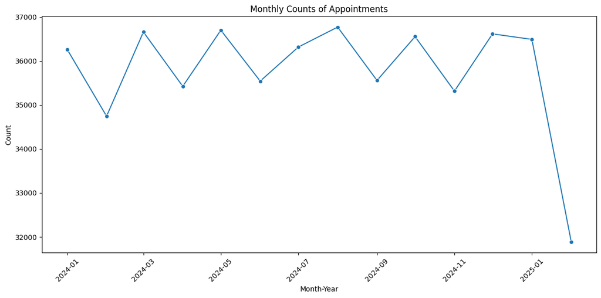

```python
plot_monthly_line(appointments_group, 'Appointments')
```

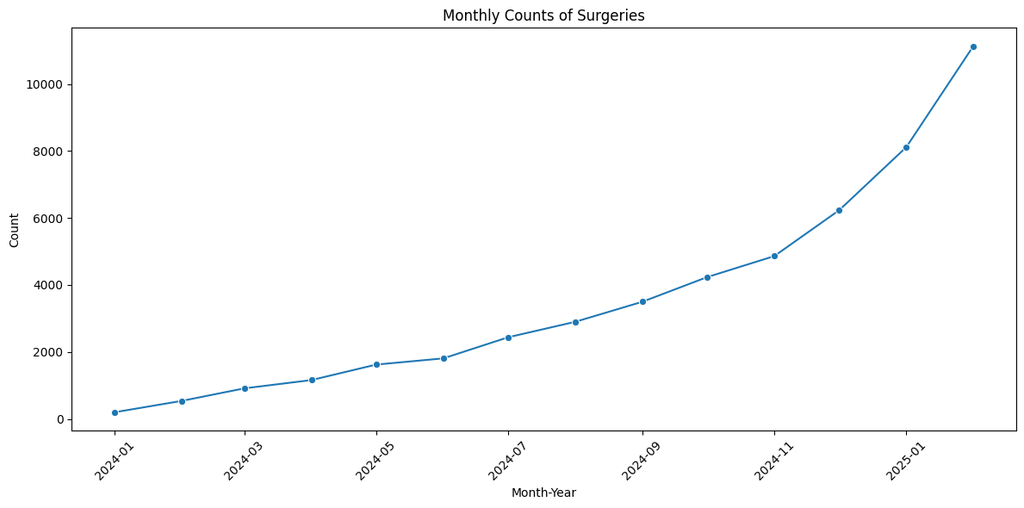

```python
plot_monthly_line(surgeries_group, 'Surgeries')
```

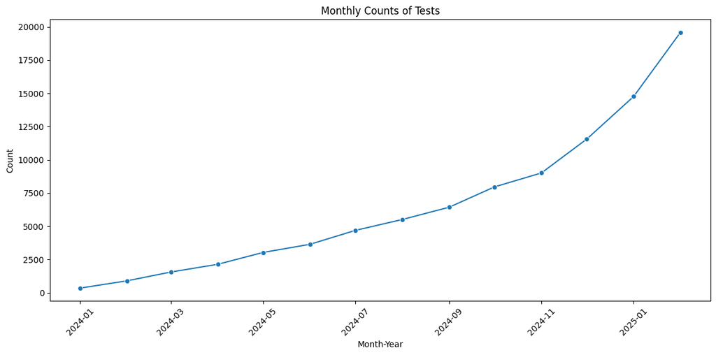

```python
plot_monthly_line(tests_group, 'Tests')
```

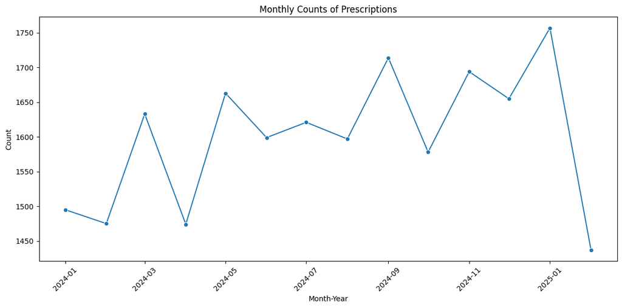

```python
plot_monthly_line(prescriptions_group, 'Prescriptions')
```

## Line chart results

The monthly counts of appointments, surgeries, tests, and prescriptions were analysed to identify temporal patterns in healthcare usage. Line charts showed that appointments fluctuate every month but generally stay the same. We can see that the number of surgeries and tests are increasing every month and while the number of prescriptions does fluctuate, we see an overall increase.

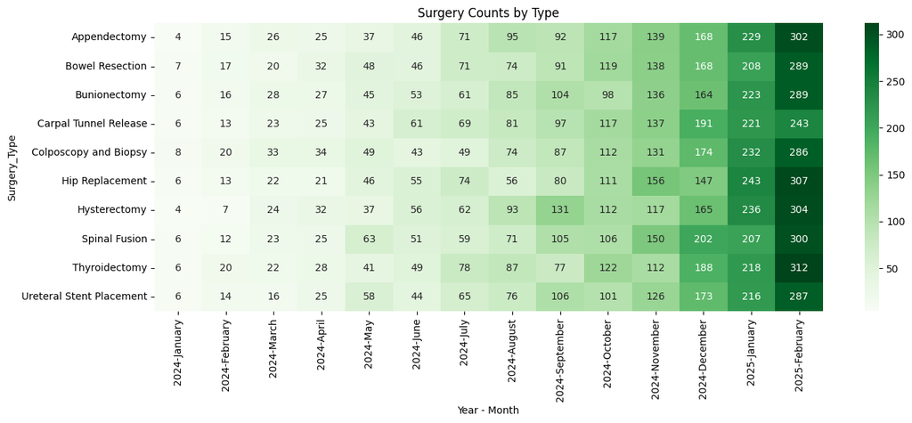

```python
plot_heatmap(surgeries, 'Surgery_Type', 'Surgery Counts by Type')
```

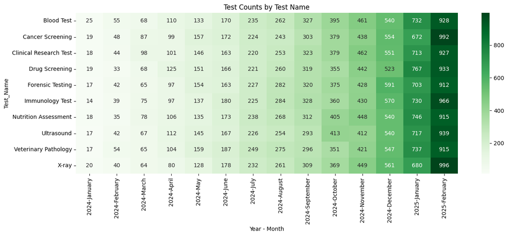

```python
plot_heatmap(tests, 'Test_Name', 'Test Counts by Test Name')
```

## Heatmap results

Heatmaps by surgery type and test name provided deeper insights, highlighting which specific procedures and tests contribute most to rising volumes.

```python
chi_squared_yearmonth(appointments, "Appointments")
```

```
Observed:

36261
36553
35315
36615
34744
36658
35423
36699
35542
36315
36770
35557
36490
31888

Expected:

35773.57142857143
35773.57142857143
35773.57142857143
35773.57142857143
35773.57142857143
35773.57142857143
35773.57142857143
35773.57142857143
35773.57142857143
35773.57142857143
35773.57142857143
35773.57142857143
35773.57142857143
35773.57142857143

Chi-square goodness-of-fit test for Appointments counts across YearMonths:
Chi2 Statistic = 603.306, p-value = 0.00000
```

```python
chi_squared_yearmonth(surgeries, "Surgeries")
```

```
Observed:

199
4235
4862
6232
538
913
1160
1623
1808
2439
2900
3498
8113
11130

Expected:

3546.4285714285716
3546.4285714285716
3546.4285714285716
3546.4285714285716
3546.4285714285716
3546.4285714285716
3546.4285714285716
3546.4285714285716
3546.4285714285716
3546.4285714285716
3546.4285714285716
3546.4285714285716
3546.4285714285716
3546.4285714285716

Chi-square goodness-of-fit test for Surgeries counts across YearMonths:
Chi2 Statistic = 36384.637, p-value = 0.00000
```

```python
chi_squared_yearmonth(tests, "Tests")
```

```
Observed:

352
7966
9014
11564
899
1561
2143
3034
3647
4694
5512
6436
14767
19599

Expected:

6513.428571428572
6513.428571428572
6513.428571428572
6513.428571428572
6513.428571428572
6513.428571428572
6513.428571428572
6513.428571428572
6513.428571428572
6513.428571428572
6513.428571428572
6513.428571428572
6513.428571428572
6513.428571428572

Chi-square goodness-of-fit test for Tests counts across YearMonths:
Chi2 Statistic = 63097.173, p-value = 0.00000
```

```python
chi_squared_yearmonth(prescription_information, "Prescriptions")
```

```
Observed:

1495
1578
1694
1655
1475
1633
1474
1663
1599
1621
1597
1714
1757
1437

Expected:

1599.4285714285713
1599.4285714285713
1599.4285714285713
1599.4285714285713
1599.4285714285713
1599.4285714285713
1599.4285714285713
1599.4285714285713
1599.4285714285713
1599.4285714285713
1599.4285714285713
1599.4285714285713
1599.4285714285713
1599.4285714285713

Chi-square goodness-of-fit test for Prescriptions counts across YearMonths:
Chi2 Statistic = 77.896, p-value = 0.00000
```

## Chi-squared results

Chi-square tests confirmed these observations, with highly significant results (p < 0.001) for all categories, indicating that monthly counts deviate substantially from a uniform distribution. Surgeries and tests showed the most pronounced upward trends, suggesting increasing demand for these services.

These findings indicate growing pressure on surgical and diagnostic services. For the NHS, this trend underscores the need for proactive resource allocation, capacity planning, and workforce management to maintain timely patient care and avoid bottlenecks, especially in surgical and testing departments where demand is accelerating.

## Limitations

The data may contain missing or inconsistent entries, especially regarding time stamps and categorical labels, which can affect the accuracy of the monthly summaries. The approach also assumes that all recorded events are equally reliable and doesn’t account for factors like holidays that might influence patterns. Lastly, focusing only on the most frequent categories may overlook less common but important events.

# Problem 3

## Problem

Cancellations reduce clinic efficiency, wasting valuable appointment slots, increasing waiting times for other patients, and driving up operational costs for the NHS. Understanding and predicting which appointments are likely to be cancelled helps optimise resource use, reduce costs, and improve patient care. Targeting patients likely to cancel with timely updates and check-ins will help reduce missed appointments.

## Solution

I built a binary classification model using logistic regression to predict appointment cancellations. The model uses data from multiple tables, including appointment and patient data. Key features include appointment timing (day and time), weekend status, and patients’ past cancellation rates. Training on a balanced dataset of attended and cancelled appointments prevents bias toward the majority class.

## Justification

Logistic regression is ideal because it offers high interpretability and reliable binary classification performance. It quantifies feature impacts, allowing NHS staff to understand key cancellation drivers. It handles both numerical and categorical data efficiently, requiring minimal computational resources. This makes it practical and scalable across NHS systems, where transparency, speed, and efficiency are crucial.

## Implementation

```python
# Importing necessary libraries
import pandas as pd
import numpy as np
from sklearn.ensemble import RandomForestClassifier
from sklearn.linear_model import LogisticRegression
from sklearn.metrics import classification_report, accuracy_score, confusion_matrix
import matplotlib.pyplot as plt
import sqlite3


con = sqlite3.connect('DATA Assessment DB.db')
```

```python
# Setting up patient and appointment data
patients = pd.read_sql('SELECT Patient_ID, Patient_Gender, Patient_Date_Of_Birth FROM Patient', con)

appointments = pd.read_sql('SELECT Patient_ID, Appointment_Time, Appointment_Date, Appointment_Status FROM Appointment', con)

con.close()

appointments = appointments[appointments['Appointment_Status'] != 'Scheduled']
appointments['Appointment_Date'] = pd.to_datetime(appointments['Appointment_Date'])
appointments['Appointment_Time'] = pd.to_datetime(appointments['Appointment_Time'], format='%H:%M').dt.time
```

```python
# Adding a flag for cancelled appointments
appointments['Is_Cancelled'] = appointments['Appointment_Status'] == 'Cancelled'
```

```python
# Merge patient data into appointments
appointments = appointments.merge(patients, left_on='Patient_ID', right_on='Patient_ID', how='left')

# Calculate patient age on the appointment date
appointments['Patient_Date_Of_Birth'] = pd.to_datetime(appointments['Patient_Date_Of_Birth'])
appointments['Patient_Age'] = (appointments['Appointment_Date'] - appointments['Patient_Date_Of_Birth']).dt.days // 365

# Encoding the patients gender
appointments['Patient_Gender'] = appointments['Patient_Gender'].map({'M': 0, 'F': 1})
```

```python
# Engineering the features of an appointment based on the date and time
appointments['Day_Of_Year'] = appointments['Appointment_Date'].dt.day_of_year
appointments['Month_Of_Year'] = appointments['Appointment_Date'].dt.month
appointments['Day_Of_Week'] = appointments['Appointment_Date'].dt.day_of_week
appointments['Hour_Of_Day'] = pd.to_datetime(appointments['Appointment_Time'], format='%H:%M:%S').dt.hour
appointments['Hour_Of_Day'] = pd.cut(appointments['Hour_Of_Day'], bins=[8, 9, 10, 11, 12, 13, 14, 15, 16, 17, 18, 19, 20], labels=False)
appointments['Is_Weekend'] = appointments['Day_Of_Week'].isin([5, 6]).astype(int)
```

```python
# Getting the cancellation rate per patient
cancel_by_patient = appointments.groupby('Patient_ID')['Is_Cancelled'].mean().reset_index(name='Patient_Cancel_Rate')
appointments = appointments.merge(cancel_by_patient, on='Patient_ID', how='left')
```

```python
# Dealing with null values by dropping them
appointments.dropna(inplace=True)
```

```python
# Split cancelled and attended into training and testing data
cancelled = appointments[appointments['Is_Cancelled']]
attended = appointments[~appointments['Is_Cancelled']]
```

```python
# Due to the imbalance in the number of cancelled appointments to completed appointments
# We will use a 50/50 split of 40,000 training examples to prevent bias towards completed appointments
cancelled_train = cancelled.sample(n=40000, random_state=42)
attended_train = attended.sample(n=40000, random_state=42)
```

```python
# Training using the rest of the data that isn't in training
cancelled_test = cancelled.drop(cancelled_train.index)
attended_test = attended.drop(attended_train.index)
```

```python
# Combine cancelled and completed appointments traning data
train_df = pd.concat([cancelled_train, attended_train])

# Combine cancelled and completed test data
test_df = pd.concat([attended_test, cancelled_test])
```

```python
# Defining our features for the logistic regression algorithm
features = ['Day_Of_Year', 'Month_Of_Year', 'Day_Of_Week', 'Hour_Of_Day', 'Is_Weekend', 'Patient_Cancel_Rate', 'Patient_Age', 'Patient_Gender']

# Setting up our traning and testing data
X_train, y_train = train_df[features], train_df['Is_Cancelled']
X_test, y_test = test_df[features], test_df['Is_Cancelled']
```

```python
# Creating our logistic regression model
logistic_model = LogisticRegression(max_iter=1000)
logistic_model.fit(X_train, y_train)

# Getting the predictions
y_pred = logistic_model.predict(X_test)
```

## Results

```python
print(f'Accuracy: {accuracy_score(y_test, y_pred)}')
```

```
Accuracy: 0.9361822056108244
```

```python
print(f'Classification Report: {classification_report(y_test, y_pred)}')
```

```
Classification Report:               precision    recall  f1-score   support

       False       1.00      0.94      0.97    373522
        True       0.19      0.91      0.32      6137

    accuracy                           0.94    379659
   macro avg       0.59      0.92      0.64    379659
weighted avg       0.99      0.94      0.96    379659
```

```python
print(f'Confusion Matrix: {confusion_matrix(y_test, y_pred)}')
```

```
Confusion Matrix: [[349852  23670]
 [   559   5578]]
```

```python
print(f'Coefficient: {logistic_model.coef_}')
```

```
Coefficient: [[ 8.86518941e-04 -2.86045749e-02  2.18818926e-02 -5.59228071e-03
  -7.47495442e-02  1.63149366e+01  1.57191530e-03  4.37500893e-02]]
```

```python
print(f'Intercept: {logistic_model.intercept_}')
```

```
Intercept: [-3.11264946]
```

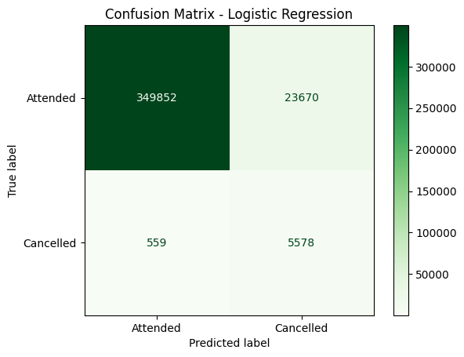

```python
from sklearn.metrics import confusion_matrix, ConfusionMatrixDisplay

y_pred = logistic_model.predict(X_test)
cm = confusion_matrix(y_test, y_pred)

disp = ConfusionMatrixDisplay(confusion_matrix=cm, display_labels=['Attended', 'Cancelled'])
disp.plot(cmap='Greens')
plt.title('Confusion Matrix - Logistic Regression')
plt.show()
```

### Classification results

Only 1.6% of test data are cancellations. Predicting all appointments as attended yields 98.4% accuracy but misses every cancellation. Our model achieved 93.6% accuracy with 91% recall on cancellations, the confusion matrix shows we correctly identified over 5,500 missed appointments with minimal false negatives. Precision is 19%, an acceptable trade-off since early identification of cancellations outweighs false alerts.

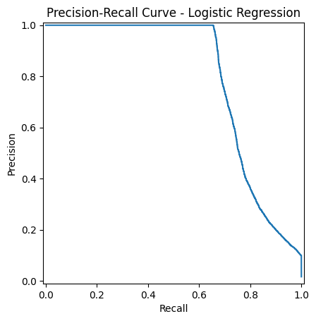

```python
from sklearn.metrics import precision_recall_curve, PrecisionRecallDisplay

y_scores = logistic_model.predict_proba(X_test)[:, 1]
precision, recall, _ = precision_recall_curve(y_test, y_scores)

disp = PrecisionRecallDisplay(precision=precision, recall=recall)
disp.plot()
plt.title('Precision-Recall Curve - Logistic Regression')
plt.show()
```

## Limitations

The model relies on historical data that may not reflect recent patient behaviour changes. Some patients have only attended one appointment, so their limited cancellation history may disproportionately influence predictions. Data limitations restrict feature inclusion, potentially missing some real-world patterns. External factors like weather or transport disruptions are not considered but could improve accuracy if incorporated in the future.

## Task 4: Ethics and Analysis (10 Marks)

**I.** (**5 marks**) Discuss the ethical implications of your modelling solutions given in Task 3. How can these ethical challenges be mitigated in a real-world NHS setting? Your answer to this question must not exceed **200 words**.

Using patient data for clustering, cancellation prediction, and trend analysis requires careful handling to avoid bias and unfair outcomes. The k-means clustering groups patients by risk using their medical histories, but if some groups are underrepresented or if data quality varies, this could lead to misclassification and unequal care. Similarly, the logistic regression model predicting appointment cancellations must work fairly for all patient groups, otherwise some patients may be unfairly targeted or overlooked. Patients with more health issues tend to have more data stored about them, which can cause their information to weigh more heavily in the results, potentially underrepresented minority or healthier groups. To reduce these risks, the models should be regularly tested for bias and accuracy across different patient groups. Healthcare professionals should be involved in reviewing the model outputs to spot any unfairness or mistakes. It’s also important that patients who have less data available or have not given consent are not ignored. Ultimately, these models should support NHS staff in making decisions, not replace their judgement, ensuring healthcare remains fair and focused on individual patient needs.

**II.** (**5 marks**) Write a Python script **using SQL** to analyse the database from Task 2 and generate results showing: *(a)* The distribution of hospitals across cities. *(b)* For each hospital, its name, city, the number of departments, and the number of patients who prefer that hospital, using outer join. Sort the hospitals within each city by the number of preferred patients in descending order.

# *(a)*

```python
import sqlite3
import pandas as pd

con = sqlite3.connect("DATA Assessment DB.db")

hospitals = pd.read_sql("SELECT * FROM Hospital", con)

hospitals["City"] = hospitals["Hospital_Location"].apply(lambda x: x.split(",")[1].strip())

hospitals.to_sql("Hospital_City", con, if_exists="replace", index=False)

city_distribution = pd.read_sql('''
SELECT City, COUNT(*) AS Hospital_Count
FROM Hospital_City
GROUP BY City
ORDER BY Hospital_Count DESC
''', con)

city_distribution
```

|  | City | Hospital_Count |
| --- | --- | --- |
| 0 | London | 93 |
| 1 | Newcastle | 15 |
| 2 | Birmingham | 12 |
| 3 | Leeds | 8 |
| 4 | Glasgow | 7 |
| 5 | Sheffield | 6 |
| 6 | Manchester | 6 |
| 7 | Edinburgh | 6 |
| 8 | Bradford | 6 |
| 9 | Liverpool | 5 |
| 10 | Bristol | 5 |
| 11 | Leicester | 4 |
| 12 | Coventry | 4 |
| 13 | Cardiff | 4 |
| 14 | Belfast | 4 |
| 15 | Wolverhampton | 3 |
| 16 | Swansea | 3 |
| 17 | Stoke-on-Trent | 3 |
| 18 | Southampton | 3 |
| 19 | Plymouth | 3 |
| 20 | Nottingham | 3 |
| 21 | Derby | 3 |
| 22 | Brighton | 3 |
| 23 | York | 2 |
| 24 | Wokingham | 2 |
| 25 | Telford | 2 |
| 26 | Swindon | 2 |
| 27 | Sunderland | 2 |
| 28 | Southend-on-Sea | 2 |
| 29 | Slough | 2 |
| 30 | Reading | 2 |
| 31 | Oxford | 2 |
| 32 | Norwich | 2 |
| 33 | Milton Keynes | 2 |
| 34 | Middlesbrough | 2 |
| 35 | Luton | 2 |
| 36 | Harrow | 2 |
| 37 | Dundee | 2 |
| 38 | Aberdeen | 2 |
| 39 | Woking | 1 |
| 40 | Wakefield | 1 |
| 41 | Redditch | 1 |
| 42 | Preston | 1 |
| 43 | Hastings | 1 |
| 44 | Exeter | 1 |
| 45 | Cheltenham | 1 |
| 46 | Cambridge | 1 |
| 47 | Blackpool | 1 |
| 48 | Basingstoke | 1 |
| 49 | Ashford | 1 |

# *(b)*

```python
df = pd.read_sql_query('''
SELECT h.Hospital_Name, h.City, COUNT(DISTINCT d.Department_ID) AS Number_of_Departments, COUNT(DISTINCT p.Patient_ID) AS Number_of_Preferred_Patients
FROM Hospital_City h
LEFT JOIN Department d ON h.Hospital_ID = d.Hospital_ID
LEFT JOIN Patient p ON h.Hospital_ID = p.Patient_Preferred_Hospital_ID
GROUP BY h.Hospital_ID
ORDER BY h.City ASC, Number_of_Preferred_Patients DESC
''', con)

pd.set_option('display.max_rows', None)
pd.set_option('display.width', 1000)
pd.set_option('display.max_colwidth', 100)

print(df)

con.close()
```

```
                                       Hospital_Name             City  Number_of_Departments  Number_of_Preferred_Patients
0                        Aberdeen NHS Trust Hospital         Aberdeen                     14                          3183
1                          Aberdeen General Hospital         Aberdeen                     14                          3146
2                         Ashford NHS Trust Hospital          Ashford                     14                          6333
3                       Basingstoke General Hospital      Basingstoke                     14                          6378
4                         Belfast NHS Trust Hospital          Belfast                     14                          1665
5         Belfast Georgina branch NHS Trust Hospital          Belfast                     14                          1619
6            Belfast Hugh islands NHS Trust Hospital          Belfast                     14                          1617
7                           Belfast General Hospital          Belfast                     14                          1579
8                       Birmingham Teaching Hospital       Birmingham                     14                           576
9          Birmingham Kelly parks NHS Trust Hospital       Birmingham                     14                           564
10     Birmingham Lindsey terrace NHS Trust Hospital       Birmingham                     14                           552
11       Birmingham Conway garden NHS Trust Hospital       Birmingham                     14                           548
12          Birmingham Lynne walk NHS Trust Hospital       Birmingham                     14                           545
13        Birmingham Abigail park NHS Trust Hospital       Birmingham                     14                           541
```

[output cut: 238 more lines]

## Overall Academic Quality (10 Marks)

10 marks are allocated for the clarity and cohesiveness of your answers (both text and code) across all tasks with appropriate, relevant and effective analysis and presentation of the results.

## Deliverables

You should submit the following to the submission point on VLE Ultra:

1. the SQLite database produced in Task 2;
2. the completed Jupyter notebook (both .ipynb and HTML files) containing solutions for all the tasks. A template has been provided on VLE;
3. any figures or diagrams that are included in your answers in the Jupyter notebook.

For each task where text is required, we have provided guidelines above on the suggested word counts. Exceeding the word count will result in any work beyond the word count being disregarded when assessing.